# Project 872

Rachael Grainger and Matthew Vining

2022-11-19

## Environmental Data Analysis of Hog Farm and Solar Farm Concentration in North Carolina

## Project Central Question:

How do communities in North Carolina experience varying levels of environmental risks and benefits, with a particular lens on environmental justice communities?

## Potential Hypothesis:

As the birthplace of the environmental justice movement, North Carolina is no stranger to environmental injustices. We expect that today Hog farms will still be correlated/concentrated in communities of higher social vulnerability (i.e., lower SES, predominantly nonwhite) across North Carolina. We also predict that energy systems, such as solar farms, will be concentrated in communities of lower social vulnerability (i.e., higher SES, predominately white) areas in North Carolina.

### Social Vulnerability Index

CDC’s Social Vulnerability Index data will be used to compare areas in North Carolina. Social Vulnerability Data: - https://www.atsdr.cdc.gov/placeandhealth/svi/documentation/SVI_documentation_2018.html - https://www.atsdr.cdc.gov/placeandhealth/svi/documentation/pdf/SVI2018Documentation-H.pdf

Brief notes: - “E_” are estimates; “M_” are margins of error - “EP_ are estimates, in percentages -”SPL_THEME1” is sum of series - “RPL_THEME1” is percentile ranking

We’ll focus on just a few variables: Estimates of people in poverty (“E_POV”) and of minority population (“E_MINRTY”), keeping the location attributes as well.

```r
#Read the 2018 SVI county-level dataset for NC
svi2018_nc_raw <- read.csv(
  'https://svi.cdc.gov/Documents/Data/2018_SVI_Data/CSV/States_Counties/NorthCarolina_COUNTY.csv',
  colClasses = c('FIPS' = 'factor')) %>%
  select(COUNTY, FIPS, LOCATION, E_TOTPOP, E_POV, E_MINRTY)

#Check structure
str(svi2018_nc_raw)
```

```
## 'data.frame':    100 obs. of  6 variables:
##  $ COUNTY  : chr  "Currituck" "Dare" "Haywood" "Clay" ...
##  $ FIPS    : Factor w/ 100 levels "37001","37003",..: 27 28 44 22 90 88 15 55 85 57 ...
##  $ LOCATION: chr  "Currituck County, North Carolina" "Dare County, North Carolina" "Haywood County, North Carolina" "Clay County, North Carolina" ...
##  $ E_TOTPOP: int  25796 35741 60433 10813 226694 33513 10447 81441 45905 34410 ...
##  $ E_POV   : int  2562 2929 8304 1700 19921 4776 1172 11593 6166 5679 ...
##  $ E_MINRTY: int  3304 4447 4300 680 62132 3249 2047 12168 4022 3684 ...
```

```r
##Create counties
counties_sf<- st_read('Project folder/Spatial/cb_2018_us_county_20m.shp') %>%
  filter(STATEFP == 37) #Filter for just NC Counties
```

```r
#Join the SVI attributes to the county spatial features
counties_sf_join <-  merge(x = counties_sf,
                           y = svi2018_nc_raw,
                           by.x = "GEOID",
                           by.y = "FIPS" )

#Tidyverse version of the join
counties_sf_join <- counties_sf %>%
  left_join(svi2018_nc_raw, by = c("GEOID" = "FIPS") )

library(leaflet)
counties_sf_join_converted <- st_transform(counties_sf_join, c=4326)

##get percents of poverty
counties_percent <- counties_sf_join_converted %>% group_by(LOCATION) %>% mutate(
                                  PovertyPerc=E_POV/E_TOTPOP, MinorityPerc=E_MINRTY/E_TOTPOP)



##Create Maps of Poverty and Minority Indicators per County



## PERCENT IN POVERTY MAP BY COUNTY
qpal = colorNumeric(palette = "plasma", counties_sf_join_converted$PovertyPerc, reverse = TRUE)

countymap_poverty <- leaflet(counties_percent) %>%
  addPolygons(stroke = TRUE,opacity = 1,fillOpacity = 0.5, smoothFactor = 0.5,
              color="black",fillColor = ~qpal(PovertyPerc),weight = 1) %>%
  addProviderTiles("Esri.WorldGrayCanvas",
        options = providerTileOptions(minZoom=6, maxZoom=10))  %>%
  addLegend("bottomright", values=~PovertyPerc*100,pal=qpal,title="Percent in Poverty", labFormat = labelFormat(suffix = "%"), opacity = 1)

countymap_poverty
```

[interactive chart not shown]

```r
## PERCENT MINORITY MAP BY COUNTY
qpal = colorNumeric( palette = "plasma", domain = counties_sf_join_converted$MinorityPerc, reverse = TRUE)

countymap_minority <- leaflet(counties_percent) %>%
  addPolygons(stroke = TRUE,opacity = 1,fillOpacity = 0.5, smoothFactor = 0.5,
              color="black",fillColor = ~qpal(MinorityPerc),weight = 1) %>%
  addProviderTiles("Esri.WorldGrayCanvas",
        options = providerTileOptions(minZoom=6, maxZoom=10)) %>%
  addLegend("bottomright", values=~MinorityPerc*100,pal=qpal,title="Percent Minority", labFormat = labelFormat(suffix = "%"), opacity = 1)

countymap_minority
```

[interactive chart not shown]

```r
##Convert hog farm data

hog_farms.sf  <- hog_farms %>%
  st_as_sf(coords = c('Longitude','Latitude'),
           crs=4326)

hog_farms.sf2 <- hog_farms.sf %>% drop_na(X)

##Map Hog Farms

##Add Counties Hog Farms
qpal2 = colorNumeric( palette = "plasma", domain = counties_sf_join_converted$MinorityPerc, reverse = TRUE)
qpal3 = colorNumeric( palette = "plasma", domain = counties_sf_join_converted$PovertyPerc, reverse = TRUE)
qpal <- colorNumeric(palette = "plasma", domain = counties_sf_join_converted$PovertyPerc, reverse = TRUE)
paltype <- colorFactor(
   palette = "#ffe9e3",
   domain = hog_farms.sf2$Type)

# Minority Level and Hog Farms
hog_farm_map1 <- leaflet() %>%
  addPolygons(data =counties_percent, stroke = TRUE,opacity = 1,fillOpacity = 0.5, smoothFactor = 0.5,
              color="black",fillColor = ~qpal(MinorityPerc),weight = 1) %>%
   addLegend("topright", data = hog_farms.sf2, pal=paltype, values=~Type,title="Farm Type") %>%
    addProviderTiles("Esri.WorldGrayCanvas",
        options = providerTileOptions(minZoom=6, maxZoom=14))  %>%
    addLabelOnlyMarkers(data = hog_farms.sf2, label = ~Facility) %>%
  addLegend("bottomright", data=counties_percent, values=~MinorityPerc*100,pal=qpal2,title="Percent Minority", labFormat = labelFormat(suffix = "%"), opacity = 1) %>%
  addCircleMarkers(data = hog_farms.sf2, radius = 3, color = "black", stroke = TRUE, weight = 1, fillOpacity = 0.8, fillColor = "#ffe9e3")

hog_farm_map1
```

[interactive chart not shown]

```r
## Poverty Level and Hog Farms

hog_farm_map_pov <- leaflet() %>%
  addPolygons(data =counties_percent, stroke = TRUE,opacity = 1,fillOpacity = 0.5, smoothFactor = 0.5,
              color="black",fillColor = ~qpal3(PovertyPerc),weight = 1) %>%
   addLegend("topright", data = hog_farms.sf2, pal=paltype, values=~Type,title="Farm Type") %>%
    addProviderTiles("Esri.WorldGrayCanvas",
        options = providerTileOptions(minZoom=6, maxZoom=14))  %>%
    addLabelOnlyMarkers(data = hog_farms.sf2, label = ~Facility) %>%
  addLegend("bottomright", data=counties_percent, values=~PovertyPerc*100,pal=qpal3,title="Percent in Poverty", labFormat = labelFormat(suffix = "%"), opacity = 1) %>%
  addCircleMarkers(data = hog_farms.sf2, radius = 3, color = "black", stroke = TRUE, weight = 1, fillOpacity = 0.8, fillColor = "#ffe9e3")

hog_farm_map_pov
```

[interactive chart not shown]

```r
##Convert data to spatial

solar_plants_NC.sf  <- solar_plants_NC %>%
  st_as_sf(coords = c('Longitude','Latitude'),
           crs=4326)

##Map Solar Farms with County Demographics

##Solar + Minority WIHTOUT HOG FARMS

paltype_solar <- colorFactor(
   palette = "#c9ffc7",
   domain = solar_plants_NC.sf$Technology)

solar_map1 <- leaflet() %>%
  addLegend(data = solar_plants_NC.sf, values=~Technology,pal=paltype_solar,title="Solar Farm Type" ) %>%
  addPolygons(data =counties_percent, stroke = TRUE,opacity = 1,fillOpacity = 0.5, smoothFactor = 0.5,
              color="black",fillColor = ~qpal(MinorityPerc),weight = 1) %>%
    addProviderTiles("Esri.WorldGrayCanvas",
        options = providerTileOptions(minZoom=6, maxZoom=14))  %>%
addLegend("bottomright", data=counties_percent, values=~MinorityPerc*100,pal=qpal2,title="Percent Minority", labFormat = labelFormat(suffix = "%"), opacity = 1)  %>%
  addCircleMarkers(data = solar_plants_NC.sf, radius = 3, color = "black", stroke = TRUE, weight = 1, fillOpacity = 0.8, fillColor = "#c9ffc7")

solar_map1
```

[interactive chart not shown]

```r
##Solar + POVERTY WIHTOUT HOG FARMS

solar_map_pov <- leaflet() %>%
  addLegend(data = solar_plants_NC.sf, values=~Technology,pal=paltype_solar,title="Solar Farm Type" ) %>%
  addPolygons(data =counties_percent, stroke = TRUE,opacity = 1,fillOpacity = 0.5, smoothFactor = 0.5,
              color="black",fillColor = ~qpal3(PovertyPerc),weight = 1) %>%
    addProviderTiles("Esri.WorldGrayCanvas",
        options = providerTileOptions(minZoom=6, maxZoom=14))  %>%
addLegend("bottomright", data=counties_percent, values=~PovertyPerc*100,pal=qpal3,title="Percent in Poverty", labFormat = labelFormat(suffix = "%"), opacity = 1)  %>%
  addCircleMarkers(data = solar_plants_NC.sf, radius = 3, color = "black", stroke = TRUE, weight = 1, fillOpacity = 0.8, fillColor = "#c9ffc7")

solar_map_pov
```

[interactive chart not shown]

```r
#Prepare hog farm data for correlation testing

Hog_SVI_merge <- hog_farms %>%
  left_join(counties_percent, by = c("County" = "COUNTY") )

Hog_SVI_merge2 <- hog_farms %>%
  group_by(County)

Hog_SVI_merge2  <- aggregate(hog_farms$Type, by=list(hog_farms$County), FUN=length)
colnames(Hog_SVI_merge2) <- c('County','Farms')

#Merge again with SVI data
Hog_SVI_cor <- Hog_SVI_merge2 %>%
  left_join(counties_percent, by = c("County" = "COUNTY"))

#Cor test hog farms

cor.test(Hog_SVI_cor$PovertyPerc, Hog_SVI_cor$Farms)
```

```
##
##  Pearson's product-moment correlation
##
## data:  Hog_SVI_cor$PovertyPerc and Hog_SVI_cor$Farms
## t = 2.9413, df = 57, p-value = 0.004717
## alternative hypothesis: true correlation is not equal to 0
## 95 percent confidence interval:
##  0.1178817 0.5664328
## sample estimates:
##       cor
## 0.3630058
```

```r
cor.test(Hog_SVI_cor$MinorityPerc, Hog_SVI_cor$Farms)
```

```
##
##  Pearson's product-moment correlation
##
## data:  Hog_SVI_cor$MinorityPerc and Hog_SVI_cor$Farms
## t = 1.2472, df = 57, p-value = 0.2174
## alternative hypothesis: true correlation is not equal to 0
## 95 percent confidence interval:
##  -0.09715553  0.40227436
## sample estimates:
##       cor
## 0.1629817
```

```r
summary(aov(Hog_SVI_cor$MinorityPerc ~ Hog_SVI_cor$Farms))
```

```
##                   Df Sum Sq Mean Sq F value Pr(>F)
## Hog_SVI_cor$Farms  1 0.0338 0.03383   1.555  0.217
## Residuals         57 1.2397 0.02175
```

```r
summary(aov(Hog_SVI_cor$PovertyPerc ~ Hog_SVI_cor$Farms))
```

```
##                   Df  Sum Sq  Mean Sq F value  Pr(>F)
## Hog_SVI_cor$Farms  1 0.01593 0.015928   8.651 0.00472 **
## Residuals         57 0.10495 0.001841
## ---
## Signif. codes:  0 '***' 0.001 '**' 0.01 '*' 0.05 '.' 0.1 ' ' 1
```

```r
## Map Hog Farms

# Hog Farms and Poverty Level
plothogpv <- lm(Farms~PovertyPerc,data=Hog_SVI_cor)
    summary(plothogpv)
```

```
##
## Call:
## lm(formula = Farms ~ PovertyPerc, data = Hog_SVI_cor)
##
## Residuals:
##    Min     1Q Median     3Q    Max
## -69.82 -35.31 -15.13  10.71 407.10
##
## Coefficients:
##             Estimate Std. Error t value Pr(>|t|)
## (Intercept)   -88.17      43.05  -2.048  0.04520 *
## PovertyPerc   685.19     232.96   2.941  0.00472 **
## ---
## Signif. codes:  0 '***' 0.001 '**' 0.01 '*' 0.05 '.' 0.1 ' ' 1
##
## Residual standard error: 80.99 on 57 degrees of freedom
## Multiple R-squared:  0.1318, Adjusted R-squared:  0.1165
## F-statistic: 8.651 on 1 and 57 DF,  p-value: 0.004717
```

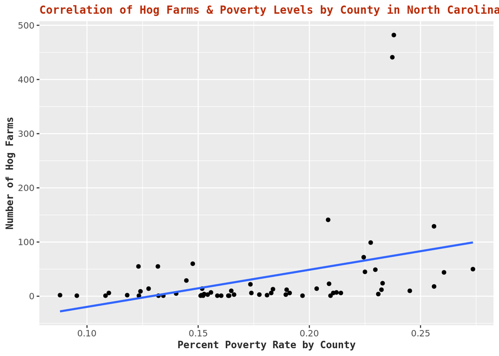

```r
plothogpov <-   ggplot(Hog_SVI_cor, aes(x=PovertyPerc, y=Farms)) +
              geom_point() +
              geom_smooth(method=lm, se=FALSE) +
              xlab("Percent Poverty Rate by County") +
              ylab("Number of Hog Farms") +
              ggtitle("Correlation of Hog Farms & Poverty Levels by County in North Carolina")


hogplot1 <- plothogpov + theme(
plot.title = element_text(color="#ba2b04", size=11, face="bold", family="mono"),
axis.title.x = element_text(color="#292929", size=10, face="bold",  family="mono"),
axis.title.y = element_text(color="#292929", size=10, face="bold", family="mono")
)

hogplot1
```

```r
## Hog Farms and Minority Level

plothogmin <-   ggplot(Hog_SVI_cor, aes(x=MinorityPerc, y=Farms)) +
              geom_point() +
              geom_smooth(method=lm, se=FALSE)

plothogmin <- lm(Farms~MinorityPerc,data=Hog_SVI_cor)
    summary(plothogpv)
```

```
##
## Call:
## lm(formula = Farms ~ PovertyPerc, data = Hog_SVI_cor)
##
## Residuals:
##    Min     1Q Median     3Q    Max
## -69.82 -35.31 -15.13  10.71 407.10
##
## Coefficients:
##             Estimate Std. Error t value Pr(>|t|)
## (Intercept)   -88.17      43.05  -2.048  0.04520 *
## PovertyPerc   685.19     232.96   2.941  0.00472 **
## ---
## Signif. codes:  0 '***' 0.001 '**' 0.01 '*' 0.05 '.' 0.1 ' ' 1
##
## Residual standard error: 80.99 on 57 degrees of freedom
## Multiple R-squared:  0.1318, Adjusted R-squared:  0.1165
## F-statistic: 8.651 on 1 and 57 DF,  p-value: 0.004717
```

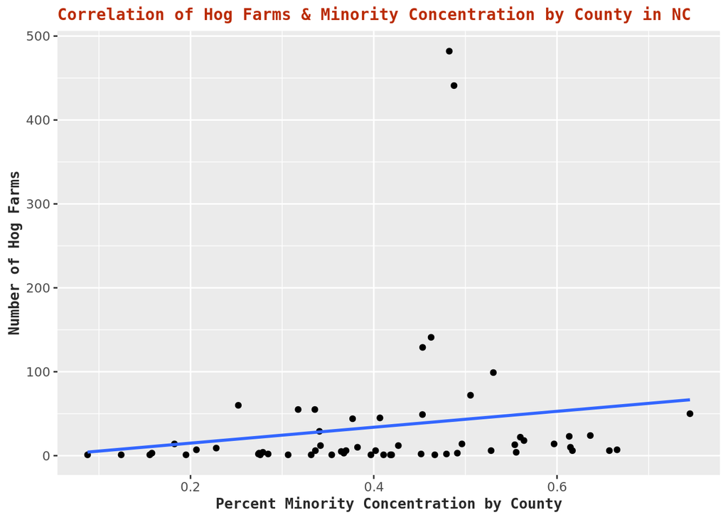

```r
plothogmin <-   ggplot(Hog_SVI_cor, aes(x=MinorityPerc, y=Farms)) +
              geom_point() +
              geom_smooth(method=lm, se=FALSE) +
              xlab("Percent Minority Concentration by County") +
              ylab("Number of Hog Farms") +
              ggtitle("Correlation of Hog Farms & Minority Concentration by County in NC")


hogplot2 <- plothogmin + theme(
plot.title = element_text(color="#ba2b04", size=11, face="bold", family="mono"),
axis.title.x = element_text(color="#292929", size=10, face="bold",  family="mono"),
axis.title.y = element_text(color="#292929", size=10, face="bold", family="mono")
)

hogplot2
```

```r
#Prepare data for solar farm correlation testing

Solar_SVI_merge <- solar_plants_NC %>%
  left_join(counties_percent, by = c("County" = "COUNTY"))

#Correlation of Solar Farm Capacity and Poverty Level

cor.test(Solar_SVI_merge$PovertyPerc, Solar_SVI_merge$`Nameplate Capacity (MW)`)
```

```
##
##  Pearson's product-moment correlation
##
## data:  Solar_SVI_merge$PovertyPerc and Solar_SVI_merge$`Nameplate Capacity (MW)`
## t = 1.7487, df = 724, p-value = 0.08077
## alternative hypothesis: true correlation is not equal to 0
## 95 percent confidence interval:
##  -0.007949082  0.136968148
## sample estimates:
##        cor
## 0.06485145
```

```r
Solar_SVI_merge %>%
  group_by(County) %>%
  summarize(cor=cor(PovertyPerc, `Nameplate Capacity (MW)`))
```

```
##          cor
## 1 0.06485145
```

```r
#Correlation of Solar Farm Capacity and Minority Level
cor.test(Solar_SVI_merge$MinorityPerc, Solar_SVI_merge$`Nameplate Capacity (MW)`)
```

```
##
##  Pearson's product-moment correlation
##
## data:  Solar_SVI_merge$MinorityPerc and Solar_SVI_merge$`Nameplate Capacity (MW)`
## t = 1.699, df = 724, p-value = 0.08976
## alternative hypothesis: true correlation is not equal to 0
## 95 percent confidence interval:
##  -0.009792301  0.135158910
## sample estimates:
##        cor
## 0.06301562
```

```r
Solar_SVI_merge %>%
  group_by(County) %>%
  summarize(cor=cor(MinorityPerc, `Nameplate Capacity (MW)`))
```

```
##          cor
## 1 0.06301562
```

```r
## Solar Plots

## Minority Concentration & Solar Farms

solarmin <- lm(`Nameplate Capacity (MW)`~MinorityPerc,data=Solar_SVI_merge)
    summary(solarmin)
```

```
##
## Call:
## lm(formula = `Nameplate Capacity (MW)` ~ MinorityPerc, data = Solar_SVI_merge)
##
## Residuals:
##    Min     1Q Median     3Q    Max
## -8.725 -4.825 -3.261 -2.318 91.351
##
## Coefficients:
##              Estimate Std. Error t value Pr(>|t|)
## (Intercept)     5.531      1.501   3.684 0.000246 ***
## MinorityPerc    5.629      3.313   1.699 0.089758 .
## ---
## Signif. codes:  0 '***' 0.001 '**' 0.01 '*' 0.05 '.' 0.1 ' ' 1
##
## Residual standard error: 14.23 on 724 degrees of freedom
## Multiple R-squared:  0.003971,   Adjusted R-squared:  0.002595
## F-statistic: 2.886 on 1 and 724 DF,  p-value: 0.08976
```

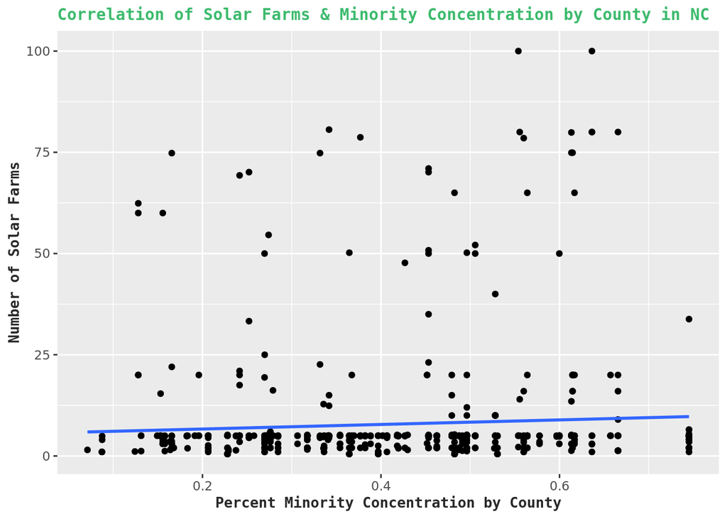

```r
solarmin_plot <-    ggplot(Solar_SVI_merge, aes(x=MinorityPerc, y=`Nameplate Capacity (MW)`)) +
              geom_point() +
              geom_smooth(method=lm, se=FALSE) +
              xlab("Percent Minority Concentration by County") +
              ylab("Number of Solar Farms") +
              ggtitle("Correlation of Solar Farms & Minority Concentration by County in NC")


solarmin_plot2 <- solarmin_plot + theme(
plot.title = element_text(color="#3cba6c", size=11, face="bold", family="mono"),
axis.title.x = element_text(color="#292929", size=10, face="bold",  family="mono"),
axis.title.y = element_text(color="#292929", size=10, face="bold", family="mono")
)

solarmin_plot2
```

```r
## Poverty & Solar Farms

solarpov <- lm(`Nameplate Capacity (MW)`~PovertyPerc,data=Solar_SVI_merge)
    summary(solarpov)
```

```
##
## Call:
## lm(formula = `Nameplate Capacity (MW)` ~ PovertyPerc, data = Solar_SVI_merge)
##
## Residuals:
##    Min     1Q Median     3Q    Max
## -8.581 -4.681 -3.407 -2.170 92.140
##
## Coefficients:
##             Estimate Std. Error t value Pr(>|t|)
## (Intercept)    4.346      2.110   2.059   0.0398 *
## PovertyPerc   19.139     10.945   1.749   0.0808 .
## ---
## Signif. codes:  0 '***' 0.001 '**' 0.01 '*' 0.05 '.' 0.1 ' ' 1
##
## Residual standard error: 14.22 on 724 degrees of freedom
## Multiple R-squared:  0.004206,   Adjusted R-squared:  0.00283
## F-statistic: 3.058 on 1 and 724 DF,  p-value: 0.08077
```

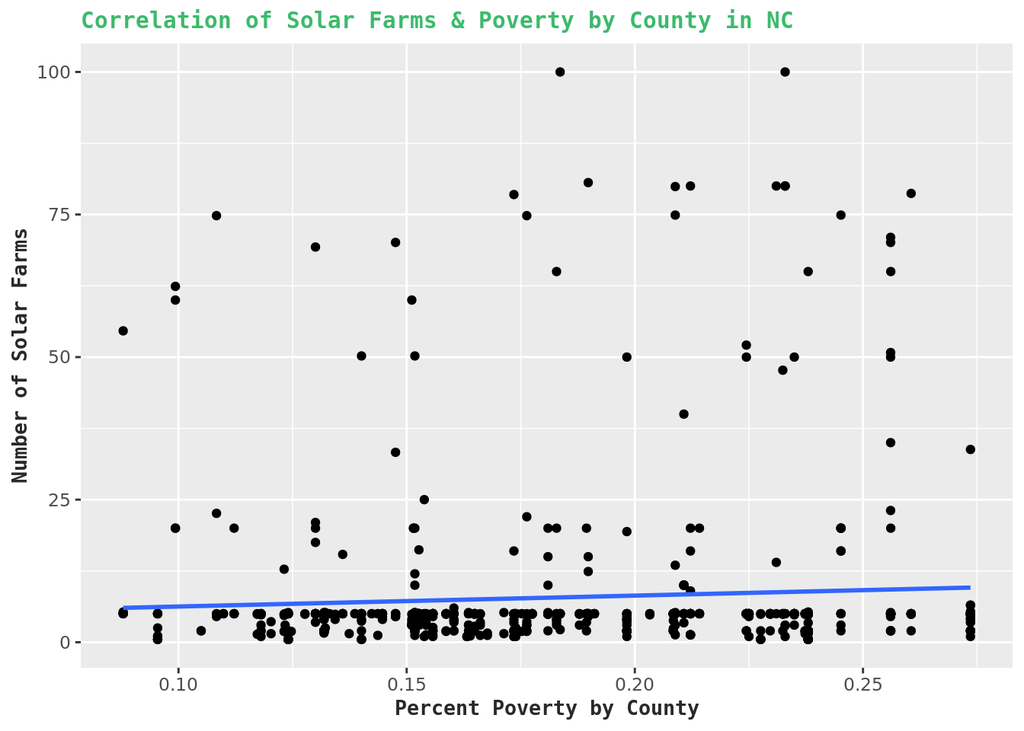

```r
solarpov_plot <-    ggplot(Solar_SVI_merge, aes(x=PovertyPerc, y=`Nameplate Capacity (MW)`)) +
              geom_point() +
              geom_smooth(method=lm, se=FALSE) +
              xlab("Percent Poverty by County") +
              ylab("Number of Solar Farms") +
              ggtitle("Correlation of Solar Farms & Poverty by County in NC")


solarpov_plot2 <- solarpov_plot + theme(
plot.title = element_text(color="#3cba6c", size=11, face="bold", family="mono"),
axis.title.x = element_text(color="#292929", size=10, face="bold",  family="mono"),
axis.title.y = element_text(color="#292929", size=10, face="bold", family="mono")
)

solarpov_plot2
```

## Summary & Conclusion

While our spatial analysis clearly indicates a concentration of hog farms in counties experiencing high poverty rates, we can decided to run a correlation and regression analysis to test the statistical significance of this concentration. We found that there is a significant presence of hog farms concentrated in counties with higher poverty levels (p-value = 0.00472). However, the R-squared value is fairly small (0.1165), which indicates there are likely other variables at play that are associated with where hog farms are concentrated in North Carolina besides just poverty levels of the county. Additionally, there is a slight correlation between hog farm concentration and higher minority concentrations, but the p-value is not significant (0.21).

Overall, we conclude that there is a significant relationship between hog farm placement and the percentage of people in poverty living in a given county. The higher the percentage of impoverished people that live in a given county, the greater chance there will be more hog farms located in that county. The relationships explored between hog farms and percent minority, solar farms and percent poverty, and solar farms and percent minority all yielded insignificant statistical analyses, although spatial analysis originally led us to believe there was a significant relationship between hog farm placement and percentage of minoritized individuals living in a given county. The team recommends adding additional factors outside of poverty and minority measures to understand the underlying factors contributing to placement of hog farms and solar farms. If a broader analysis is done, incorporating more variables, a stronger relationship may be revealed. Things to explore may include why poverty is correlated well with hog farm placement? Are there environmental and geographic factors that lead to solar farm and hog farm placement we were not aware of (slope, vegetation, etc)? It would further be interesting to apply a time series analysis to hog and solar farm placements to see which periods of time contained the greatest threat or benefit to human and environmental safety.